# Modelling COVID-19 in South Africa at a Provincial Level

# 1 Introduction

This paper documents a model of the COVID-19 epidemic in South Africa. Mobility data is used to model the reproduction number of the COVID-19 epidemic over time using Bayesian hierarchical model. Results are calibrated to reported deaths only. This is achieved by adapting the work in [1] for South Africa. Similar models have been built for Brazil [2] and the United States [3].

The model is based on data as compiled in [4]. The model uses mobility movement indexes by province from [5]. The model and report are automatically generated on a regular basis using R [6]. This version contains data available on 31 May 2020.

An online, regularly updated version of this report is [available here](https://lrossouw.github.io/covid-19/modelling_covid-19_in_south_africa_at_a_provinical_level.html?utm_source=paper&utm_medium=paper_url&utm_campaign=week1).

# 2 Methodology

Key features of the approach employed are:

- It uses a Bayesian Hierarchical Model to calibrate model parameters based on observed death data and prior assumptions.
- Changes in the reproductive number are linked to mobility data [5].
- The model uses population weighted infection fatality ratio (IFRs) with some noise added.
- There is a single model for all provinces sharing information between provinces, but province specific effects are also allowed.
- The model does not allow for interventions that are not observable via mobility changes. This includes testing and contact tracing, mask wearing, workplace screening etc.

See a more detailed description of the methodology and assumptions below.

# 3 Mobility

Below we show the mobility data from [5]. We use the indexes at a provincial level but here we plot the national indexes.

## 3.1 Residential

Below we plot the mobility data from [5] for South Africa as a whole. Clear trends are observable over:

- Mobility generally reduces before the lockdown on 27 March.
- There is an increase in mobility in the days just before the lockdown. In particular the Grocery & Pharmacy and Retail indexes. Perhaps an indication of pre-lockdown “panic buying”?
- Mobility is relatively stable during level 5 lockdown at low levels.
- Mobility increases when level 4 starts.

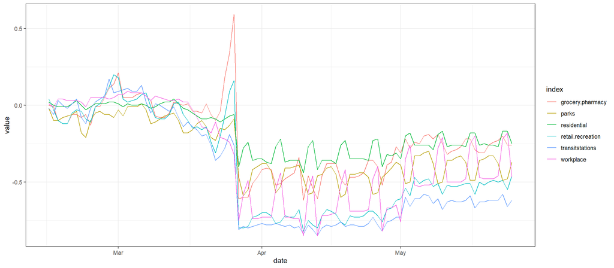

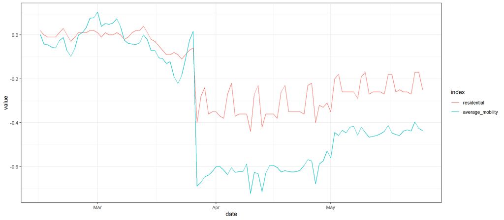

We do not show them separately, but, in the model, we use the provincial versions of these indexes.

# 4 Calibration

This section shows the calibration of data for various provinces. Three panels are plotted for each province:

1. The first panel shows the modelled daily number of infections (blue) compared to confirmed case counts (brown) as reported for the province. Note that this model does not calibrate to case data, but this data is shown for reference.
2. The second shows the daily count of deaths reported in the province (brown) and the modelled deaths in blue.
3. The third panel shows the estimates for $R_{t,m}$ for each province.

In all the charts the darker shaded area represents a confidence interval of 50% and the lighter shaded area represents a confidence interval of 95%.

In general, it is noted:

- The model appears to be a reasonable fit to daily number of deaths reported (where there is enough data).
- $R_{t,m}$ dropped significantly from the declaration of state of disaster, closure of schools and the implementation of lockdown.
- $R_{t,m}$ picked up in the days ahead of the start of Level 5 lockdown, presumably as people prepared for lockdown.
- $R_{t,m}$ dropped significantly during Level 5 lockdown. For most provinces it did not drop below 1.
- $R_{t,m}$ moved higher after the start of Level 4 lockdown.

## 4.1 Western Cape

The Western Cape has the most reported deaths of all provinces and hence the most data to calibrate. Below we plot the modelled infections. It’s clear that infections are far outpacing reported cases. Over the last 14 days it would appear that the Western Cape only tested 2.7% of all new infections.

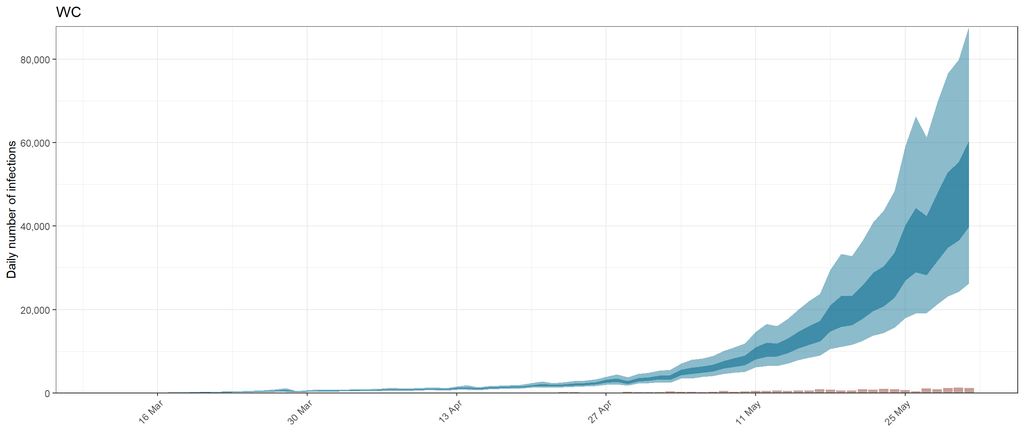

Below we plot reported deaths in brown vs. modelled deaths in blue. This province has increasing numbers of deaths. The model appears to have a reasonable fit. The data does seem quite variable from day to day which may be perhaps data processing delays causing clumping of reported deaths.

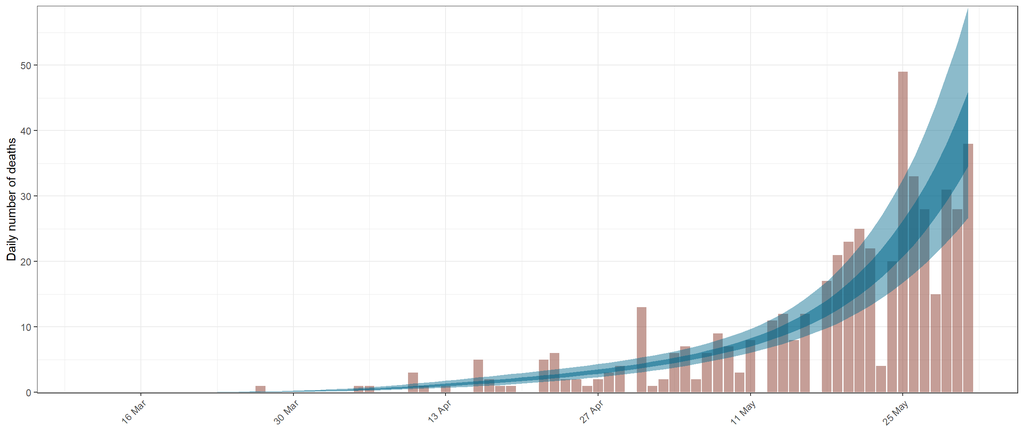

Western Cape $R_{t,m}$ is currently in a band between 1.5 and 2.0 after never truly moving much below 1.5. Thus, we are probably dealing with an already rapidly spreading epidemic.

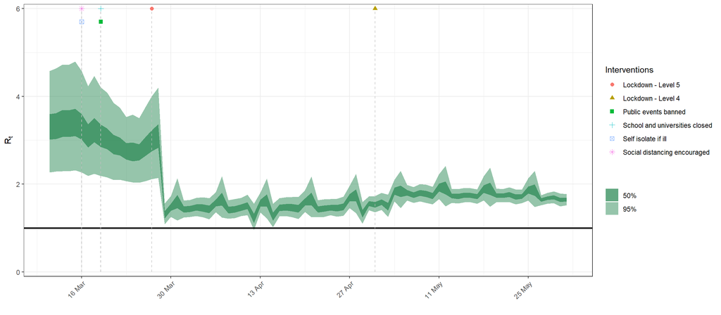

## 4.2 Eastern Cape

Eastern Cape also has a recently had an increase in deaths. Data is still relatively sparse, but the model is clearly trending upwards to accommodate more frequent reporting of deaths. $R_{t,m}$ for Eastern Cape appears to be slightly higher than Western Cape. A concerning trend. Over the last 14 days it would appear that 3.1% of all new infections were tested.

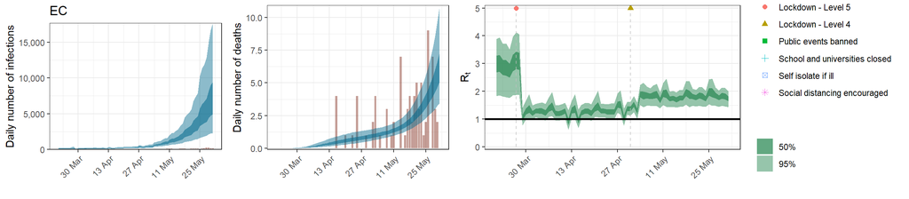

## 4.3 Gauteng

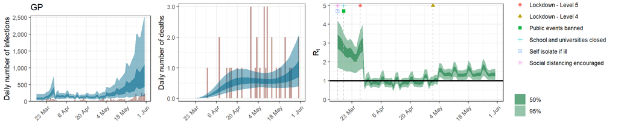

## 4.4 KwaZulu-Natal

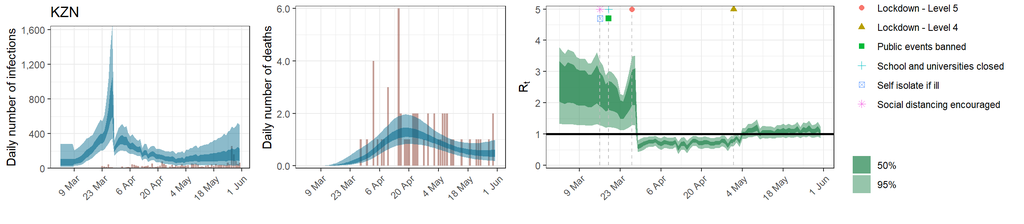

## 4.5 Other Provinces

The other provinces have extremely limited data. We should await more deaths to form a conclusive opinion on these provinces. Over the last 14 days it would appear that 18.7% of all new infections were tested.

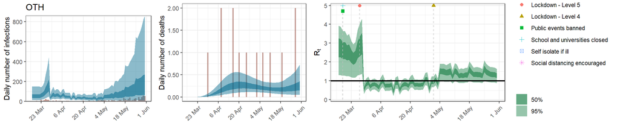

# 5 Reproduction Number Estimates

## 5.1 Initial Reproduction Number

Below we plot estimates for $R_{0,m}$ for each province. It is clear that the posterior estimates for $R_{0,m}$ is not heavily influenced by the data. This is probably due to the relatively early lockdown implemented in South Africa. There were probably not enough deaths that resulted from infection prior to lockdown to develop an independent estimate for each province of $R_{0,m}$.

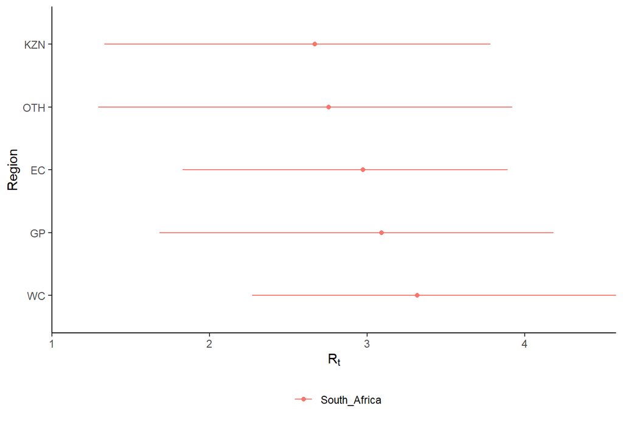

## 5.2 Current Reproduction Number as at 31 May 2020

Below we plot current estimates and 95% confidence intervals for $R_{t,m}$ (current reproduction number) for each province. It’s clear that currently the values of $R_{t,m}$ are not below 1 (which would indicate an epidemic that is slowing). Only KwaZulu-Natal and Other provinces confidence intervals include 1. It is however clear that the spread of the epidemic is somewhat slowed compared to the initial $R_{0,m}$.

The wide confidence intervals would indicate that we need to wait for the epidemic to further develop to include more data in our models. The confidence intervals for Western Cape is narrowing already.

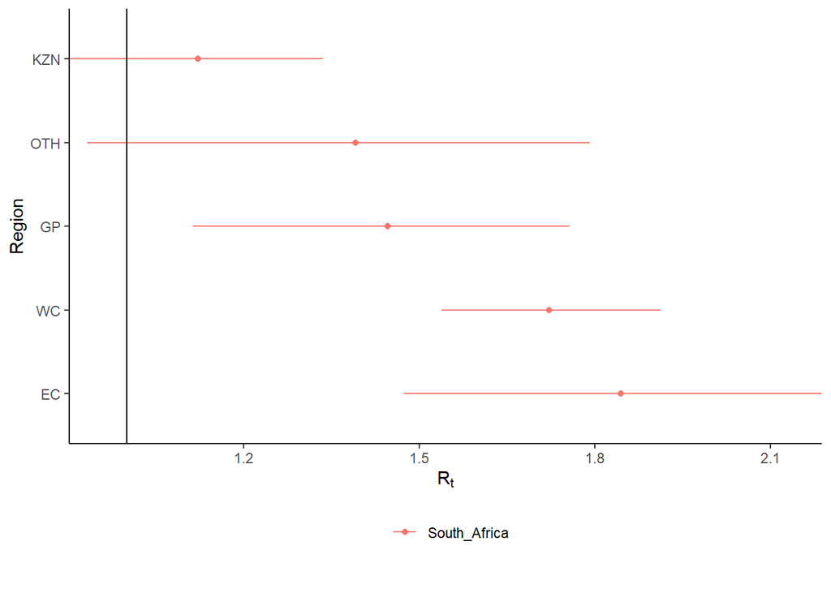

# 6 Attack Ratio as at 31 May 2020

The estimated attack ratio (with 95% confidence intervals) is tabulated below. This is the proportion of the population infected to date. This figure has to be estimated, because many that are infected experience no or mild symptoms, thus they may not seek medical advice and hence will never be tested.

Western Cape has the highest estimated prevalence to date, but with fairly wide confidence intervals. Eastern Cape has the second highest prevalence.

| Province | Attack Ratio |
| --- | --- |
| EC | 1.33% [0.61%-2.58%] |
| GP | 0.13% [0.06%-0.26%] |
| KZN | 0.15% [0.10%-0.22%] |
| WC | 9.36% [5.52%-14.96%] |
| OTH | 0.03% [0.01%-0.07%] |
| South Africa | 1.31% [0.84%-1.95%] |

# 7 Projections

One of the reasons we build models is so that we can make sense of the future or indeed the past. We can project forward models and assess the impact of varying assumptions on future outcomes to get a sense of how changes in actions may impact the future. I.e. it allows us to answer “what if” questions.

Note however that in projecting the future (or indeed alternate pasts) we are extrapolating, and due care needs to be taken.

## 7.1 No change in Mobility

The first projections holds mobility constant at current levels. This is somewhat unrealistic given the move to level 3 lockdown on 1 June.

Below we plot that results by 31 December 2020. Eastern Cape and Western Cape are projected to have a high attack ratios and high numbers of deaths.

Other provinces fare better albeit the confidence intervals in these provinces are extremely wide. This model also does not include the possibility of infections across provincial borders.

| Province | Attack Ratio | Deaths | Peak Daily Deaths | Peak Date |
| --- | --- | --- | --- | --- |
| EC | 74.48% [57.94%-83.76%] | 29 554 [21 492-36 982] | 561 | 2020-08-02 |
| GP | 47.52% [1.44%-70.27%] | 27 142 [ 615-43 712] | 277 | 2020-10-02 |
| KZN | 6.10% [0.15%-36.54%] | 2 126 [ 66-14 689] | 26 | 2021-01-12 |
| WC | 75.29% [67.70%-81.64%] | 24 527 [19 416-29 820] | 505 | 2020-07-13 |
| OTH | 33.38% [0.02%-70.46%] | 24 992 [ 19-60 340] | 243 | 2020-10-22 |

## 7.2 Increase in mobility

Below we tabulate attack ratio and deaths by 31 December 2020 after increasing mobility 50% back to normal. I.e. this is half-way between current mobility levels and normal levels.

In terms of attack ratios Eastern Cape and Western Cape are increased a bit, but other provinces have a large increase. The same occurs to deaths. Similarly, the deaths peak at higher level in all provinces and these peaks occur sooner. The confidence intervals remain wide. The lower end of the confidence range of Gauteng however increase significantly away from 0.

| Province | Attack Ratio | Deaths | Peak Daily Deaths | Peak Date |
| --- | --- | --- | --- | --- |
| EC | 87.86% [69.63%-94.89%] | 34 869 [25 487-42 951] | 890 | 2020-07-22 |
| GP | 81.71% [50.07%-92.14%] | 48 688 [28 212-62 064] | 980 | 2020-08-16 |
| KZN | 64.70% [1.09%-86.06%] | 28 747 [ 379-42 571] | 424 | 2020-09-05 |
| WC | 89.64% [79.87%-95.58%] | 29 206 [23 110-35 114] | 799 | 2020-07-08 |
| OTH | 74.85% [0.21%-92.35%] | 61 739 [ 121-85 536] | 1 009 | 2020-08-29 |

## 7.3 Western Cape

The next 30 days the attack ratio and deaths are increasing rapidly. The model predicts that within 30 days it is likely that deaths will exceed 200 per day and that more than 30% of the Western Cape population may be infected.

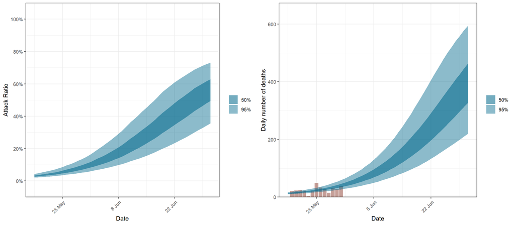

The attack ratio and deaths over a longer period for both the constant mobility and increased mobility scenarios are plotted below:

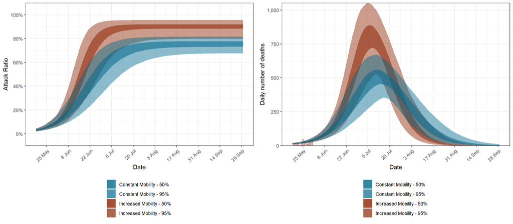

## 7.4 Eastern Cape

In the Eastern Cape, the attack ratio and deaths are predicted to increase rapidly over the coming 30 days. The model predicts that it is likely that within 30 days deaths will exceed 200 per day in this province.

[figure not shown]

Below we plot the attack ratio and deaths over a longer period for both the constant mobility and increased mobility scenarios.

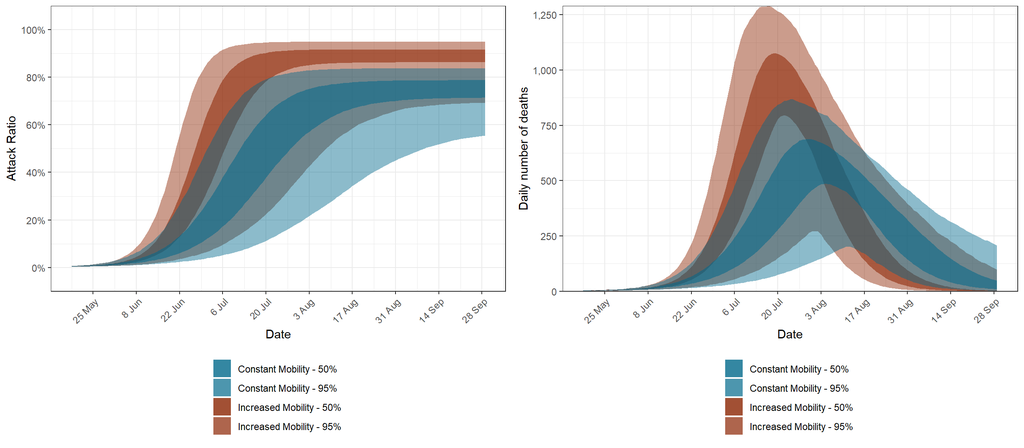

## 7.5 Other provinces

The other provinces have fairly wide confidence intervals and are not plotted here.

# 8 Discussion

## 8.2 Impact of Interventions

From the results it’s clear that $R_{t,m}$ in all provinces has likely been reduced from $R_{0,m}$ and this has slowed the spread of the epidemic in South Africa saving lives. However, in Europe the lockdowns have been able to reduce $R_{t}$ for various countries below 1 [8]. South Africa’s lockdowns and other interventions have not been as successful as in most European countries.

## 8.3 Lockdown - Level 4

Mobility has increased somewhat following the commencement of level 4 lockdowns. This results in an increasing the $R_{t,m}$ in various provinces since the start of May. The death data corresponding to this increased $R_{t,m}$ is unlikely to be significant as yet and we will soon see whether this model is handling this accurately, or if potentially through other interventions the Level 4 is not increasing $R_{t,m}$.

## 8.4 Further relaxation of lockdown

Projections on current mobility levels would already result in significant peaks in deaths in July and August in Western cape and Eastern Cape. Further relaxation of lockdowns will result in further increases in mobility. Projecting and increase from current mobility 50% back to normal mobility would and would worsen the epidemic significantly in Gauteng and marginally in western Cape and Eastern Cape. Other provinces have wide confidence intervals.

## 8.5 Differences between provinces

The large differences between the various provinces was surprising. Given the high prevalence in the Western Cape it may be prudent to enforce some screening or travel restrictions out of the province.

## 8.6 Relevance of IFR

The IFR is not treated as a parameter but as a constant with random noise. Changes to the IFR will change the modelled infections that correlate with the observed deaths. Sensitivity to the IFR could be modelled.

## 8.7 Using mobility data

Using mobility data is useful to not only measure the impact of government interventions but also include the societal response to those interventions (as they affect mobility). This means that changes in the reaction to new regulations can be modelled. It may also be useful going forward as many new regulations are introduced possibly at a provincial level to summarise the impact of interventions numerically.

## 8.8 Untangling mobility and other interventions

This paper projects mobility changes forward. The implicit assumptions is that a return to normal mobility will result in an unimpeded epidemic. However, this is not likely to be the case as other interventions may make a difference. Thus it may make sense to incorporate other indicators of interventions that may slow the spread of the epidemic as mobility increases.

For example, a consideration is an indicator variable for the implementation of compulsory mask wearing, and workplace screening. It may also be possibly to try and model contract tracing, testing and isolation.

## 8.9 Health system capacity

As ICU capacity is exhausted in the Western Cape it would seem likely that the mortality rate of infected individuals in the Western Cape would increase. This model needs to take account of that for two reasons:

1. Given the relationships between deaths and infections in this model as sudden increase in deaths due to capacity constraints would incorrectly be treated as a rise in infections.
2. To project forward accurately the expected deaths this model needs to allow for future capacity constraints as well.

## 8.10 Further Work

The author intends to investigate the following:

- Search and include further indexes that may track other interventions to model their effect.
- Produce similar models for a selection of countries.
- Back test earlier models against new data.
- Analyse the sensitivity of results to changes in IFR.
- Consider spreading deaths backwards based on estimated reporting delays.

# 9 Detailed Assumptions and Methodology

The model assumes that current reproduction number, $R_{t,m}$, is a function of the initial reproduction number, $R_{0,m}$, and mobility changes over time. It then calculates infections as a function of $R_{t,m}$ over time, and then, using these infections calculates deaths from the infections based on a distribution of time to death. Various prior distributions are assumed. The model structure is identical to that in [1] but is briefly documented below. The parameters are estimated jointly using a single hierarchical model covering all provinces. This means that data in different provinces are combined to inform all parameters in the model. As per [1], fitting was done in R using Stan with an adaptive Hamiltonian Monte Carlo sampler.

## 9.1 The Model

The model assumes a base reproduction number ($R_{0,m}$) for each province ($m$) and then it models future values of the reproduction number using mobility indexes as follows:

$R_{t,m}=R_{0,m}(\phi^{-1}(-\sum_{k=1}^{3}(\alpha_{k}+\beta_{k,m})I_{k,t,m}))$

Here:

- $t$ is the day.
- $\phi^{-1}$ is the inverse logit function.
- $I_{k,t,m}$ are the mobility indexes from Google Mobility [5] data for each province over time. Typical movements are presented by 0 and atypically movements are represented by increases or decreases to the above.
- $\alpha_{k}$ is the effect of mobility index $I_{k,t,m}$ on $R_{t,m}$ independent of province.
- $\beta_{k,m}$ is the province specific effect of mobility index $I_{k,t,m}$ on $R_{t,m}$.

Infections are modelled as:

$c_{t,m}=S_{t,m}R_{t,m}\sum_{\tau=0}^{t-1}c_{\tau,m}g_{t-\tau}$ where $S_{t,m}=1 - \frac{\sum_{i=0}^{t-1}c_{i,m}}{N_{m}}$.

Infections, $c_{t,m}$ at time $t$ are a function of proportion of population not yet infected ($S_{t,m}$), the reproduction number ($R_{t,m}$) and infections prior to that $c_{\tau,m}$ as well as an infectiousness curve $g_{t-\tau}$. $N_m$ is the population in province $m$.

Deaths, $d_{t,m}$ are modelled as:

$d_{t,m}=ifr_{m}^*\sum_{\tau=0}^{t-1}c_{\tau,m}\pi_{t-\tau}$

Here:

- $ifr_{m}^*$ is the average infection fatality rate (IFR) in the province (with random noise added).
- $\pi_{t-\tau}$ is a distribution of time to death since infection.

## 9.2 Prior Assumptions and Random Noise

The following assumptions are taken as is from [1].

We add random noise to the IFR as follows:

$ifr_{m}^*=ifr_{m}\cdot N(1,0.1)$

$\alpha_{k}$ is normally distributed with a 0 mean:

$\alpha_{k} \sim N(0,0.5)$

If $Y \sim N(\mu,\sigma)$ then we define $N^{+}$ to mean the distribution of $|Y| \sim N^{+}(0,0.5)$.

Then for the provincial specific index effects we use:

$\beta_{k,m} \sim N(0,\gamma)$ with $\gamma \sim N^{+}(0,0.5)$

The $R_{0,m}$ are defined to be distributed normally as follows:

$R_{0,m} \sim N(3.28,\kappa)$ with $\kappa \sim N^{+}(0,0.5)$

Infectiousness follows this distribution:

$g \sim Gamma(6.5,0.62)$

Time to death follows this distribution:

$\pi \sim Gamma(5.1,0.86)+Gamma(17.8,0.45)$

## 9.3 Death and Confirmed Case Data

Death and case data were used from [4]. This data set contains, amongst other, provincial case and deaths data digitised mainly from daily tweets by National Institute of Communicable Diseases (NICD).

We note again that the model calibrates to only the deaths. The reason for not calibrating to confirmed cases is that the bias in the testing is unknown. The degree to which testing has focussed on symptomatic and people seeking medical treatment or hospital treatment is unknown and could have changed over time. This would present a biased estimate and would require adjustment in this model.

Based on limited death data, provinces were aggregated as follows:

- EC – Eastern Cape
- GP – Gauteng
- KZN – KwaZulu Natal
- WC – Western Cape
- OTH (all other provinces)

## 9.4 Infection Fatality Rates (IFR)

The IFR ($ifr_{m}$) for each province was calculated using the output of the squire R package [9]. It produces an age-specific infection attack ratios (IAR), infections and deaths. The per age band IFR were used together with the per age band IAR and these were applied to provincial populations [10]. The IFRs from squire package are based on [11], [12] and [9].

The projection was done doing the default parameters for South Africa and the resultant attack ratio ($a_{x}$) and IFR ($ifr_{x}$) for each 5-year age band was obtained ($x$).

These $a_{x}$ and $ifr_{x}$ were then applied to the South African population per province and age band as per [10] and weighted IFRs calculated as follows.

$ifr_{m}=\frac{\sum_{x}N_{x,m} \cdot a_{x} \cdot ifr_{x}}{\sum_{x}N_{x,m}}$

Here $N_{x,m}$ is the population in a particular province ($m$) and age band ($x$).

Below we tabulate the resultant $ifr_{m}$:

| Province | IFR |
| --- | --- |
| EC | 0.59% |
| GP | 0.39% |
| KZN | 0.4% |
| WC | 0.48% |
| OTH | 0.44% |
| South Africa | 0.44% |

The differences between provinces reflect the different age profiles in those provinces as per [10]. This seems low compared to the IFRs in [7], but may be reasonable given the younger profile of the South African population.

## 9.5 Mobility Indexes

These data contain the mobility indexes for each province. These are described in [5] as follows:

- Grocery & pharmacy: Mobility trends for places like grocery markets, food warehouses, farmers markets, specialty food shops, drug stores, and pharmacies.
- Parks: Mobility trends for places like local parks, national parks, public beaches, marinas, dog parks, plazas, and public gardens.
- Transit stations: Mobility trends for places like public transport hubs such as subway, bus, and train stations.
- Retail & recreation: Mobility trends for places like restaurants, cafes, shopping centres, theme parks, museums, libraries, and movie theatres.
- Residential: Mobility trends for places of residence.
- Workplaces: Mobility trends for places of work.

These measure relative changes in mobility in above dimensions relative to a baseline established before the epidemic. For example, -30% implies a 30% reduction in mobility from pre-COVID-19 mobility.

As per [1] these data were combined into 2 indexes for each province as follows:

- Residential
- Average of the rest

In [1] three indexes were used (Residential, Transit and the rest). This was reduced for this paper due to limited data.

We calculated indexes for OTH by weighting the individual provinces by population.

# 10 Author

This report was prepared by Louis Rossouw. Please get in contact with Louis Rossouw if you have comments or wish to receive this regularly.

**Louis Rossouw**  
Head of Research & Analytics  
Gen Re | Life/Health Canada, South Africa, Australia, NZ, UK & Ireland  
Email: LRossouw@GenRe.com Mobile: +27 71 355 2550

*The views in this document represents that of the author and may not represent those of Gen Re. Also note that given the significant uncertainty involved with the parameters, data and methodology care should be taken with these numbers and any use of these numbers.*

# References

[1] Volmer et al., “Report 20 - using mobility to estimate the transmission intensity of COVID-19 in Italy: A subnational analysis with future scenarios,” Imperial College, London, 2020 [Online]. Available: https://www.imperial.ac.uk/mrc-global-infectious-disease-analysis/covid-19/report-20-italy/

[2] Mellan et al., “Report 21: Estimating COVID-19 cases and reproduction number in brazil,” Imperial College, London, 2020 [Online]. Available: https://www.imperial.ac.uk/mrc-global-infectious-disease-analysis/covid-19/report-21-brazil/

[3] Unwin et al., “Report 23 - state-level tracking of COVID-19 in the united states,” Imperial College, London, 2020 [Online]. Available: https://www.imperial.ac.uk/mrc-global-infectious-disease-analysis/covid-19/report-23-united-states/

[4] Marivate et al., “Coronavirus disease (COVID-19) case data - South Africa.” [Online]. Available: https://github.com/dsfsi/covid19za

[5] Google LLC, “Google covid-19 community mobility reports.” [Online]. Available: https://www.google.com/covid19/mobility/

[6] R Core Team, *R: A language and environment for statistical computing*. Vienna, Austria: R Foundation for Statistical Computing, 2019 [Online]. Available: https://www.R-project.org/

[7] G. Meyerowitz-Katz and L. Merone, “A systematic review and meta-analysis of published research data on COVID-19 infection-fatality rates,” Cold Spring Harbor Laboratory Press, 2020 [Online]. Available: https://www.medrxiv.org/content/early/2020/05/27/2020.05.03.20089854

[8] Flaxman et al., “Report 13 - estimating the number of infections and the impact of non-pharmaceutical interventions on COVID-19 in 11 European countries,” Imperial College, London, 2020 [Online]. Available: https://www.imperial.ac.uk/mrc-global-infectious-disease-analysis/covid-19/report-13-europe-npi-impact/

[9] Walker et al., “Report 12 - the global impact of COVID-19 and strategies for mitigation and suppression,” Imperial College, London, 2020 [Online]. Available: https://www.imperial.ac.uk/mrc-global-infectious-disease-analysis/covid-19/report-12-global-impact-covid-19/

[10] Statistics South Africa, “Mid-year population estimates 2019,” Republic of South Africa, London, 2019.

[11] Verity et al., “Estimates of the severity of coronavirus disease 2019: A model-based analysis,” *The Lancet Infectious Diseases*, 2020 [Online]. Available: https://www.thelancet.com/journals/laninf/article/PIIS1473-3099(20)30243-7/fulltext

[12] Ferguson et al., “Report 9 - impact of non-pharmaceutical interventions (NPIs) to reduce COVID-19 mortality and healthcare demand,” Imperial College, London, 2020 [Online]. Available: https://www.imperial.ac.uk/mrc-global-infectious-disease-analysis/covid-19/report-9-impact-of-npis-on-covid-19/